# TidyBiology_Final Project_CRISPR Screen_Aiduk

2023-11-02

#Load library and import data # CRISPR-Cas9 negative selection gene essentiality screen to investiagte genetic perturbations that affect survical of CIC-DUX4 sarcoma cell lines. Here, I am visualziing the gene dependency scores obtained using the algorithm Model-based Analysis of Genome-wide CRISPR-Cas9 Knockout (MAGeCK) (Li et al. Genome Biol. 2014)

#Exploratory Data Analysis #Visualizing >18500 human genes on the x axis with their essentially score on the y axis.

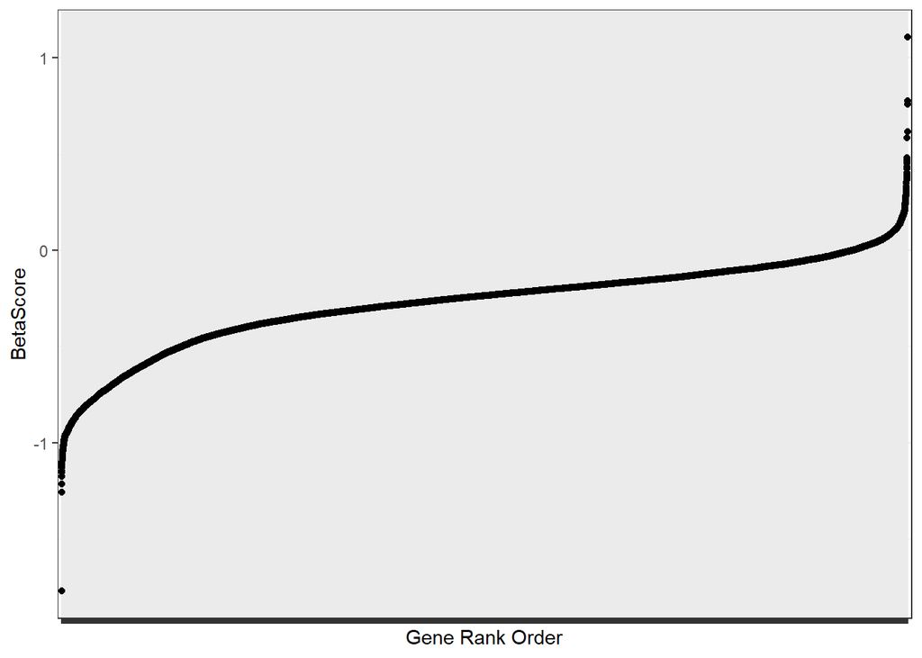

```r
ggplot(KitraScreen_v2) +
  geom_point(aes(x = reorder(Gene, BetaScore), y = BetaScore)) +
  labs(x = "Gene Rank Order", y = "BetaScore") +
  theme_bw() +
  theme(axis.text.x = element_blank()) +
  scale_x_discrete(expand = c(.005, .005))
```

#Low beta score indicates when gene is lost the cell viability is diminished, while high beta score indicates increased cell viability with loss of gene.

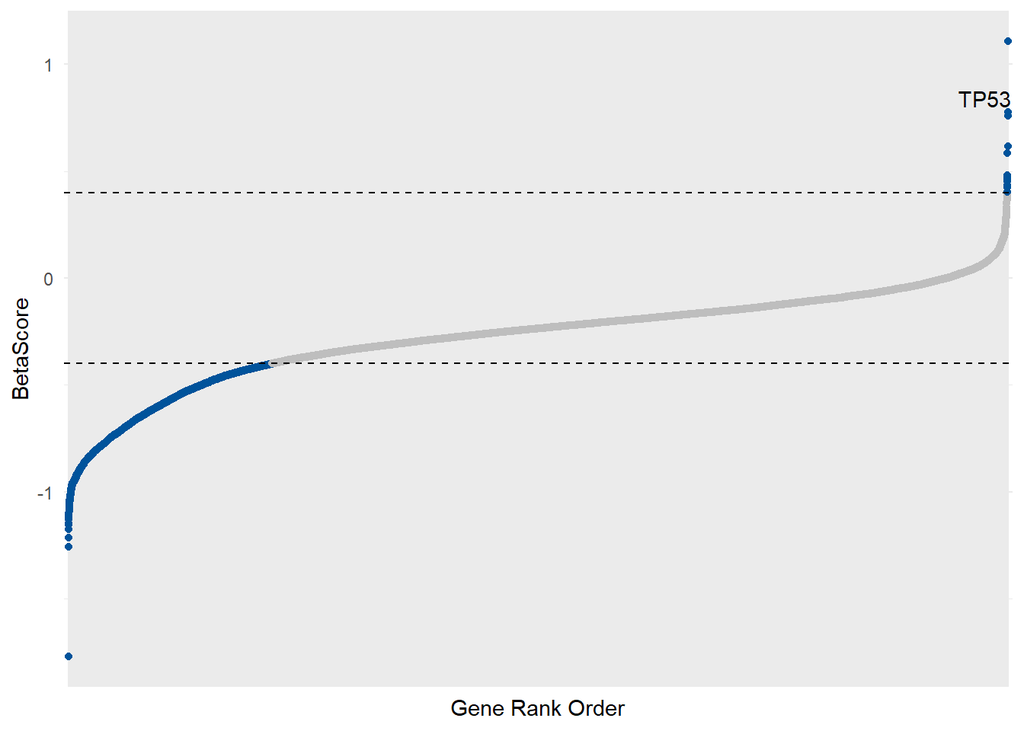

```r
ggplot(KitraScreen_v2) +
  geom_point(aes(x = reorder(Gene, BetaScore), y = BetaScore, color = if_else(BetaScore >= -.4 & BetaScore <= .4, "In Range", "Out of Range"))) +
  scale_color_manual(values = c("In Range" = "gray", "Out of Range" = "#00539B")) +
  labs(x = "Gene Rank Order", y = "BetaScore") +
  scale_x_discrete(expand = c(.005, .005)) +
  theme_minimal() +
  theme(axis.text.x = element_blank()) +
  theme(legend.position = "none") +
  geom_hline(yintercept = c(-.4, .4), linetype = "dashed") +
  annotate("text", x= 18300, y=.84, label = "TP53")
```

#Highlighting the common essential genes across cancer subtypes and lines defined by Broad Institute’s DepMap. These are uninteresting in regards to therapeutic targets and tumor-specific novel discoveries

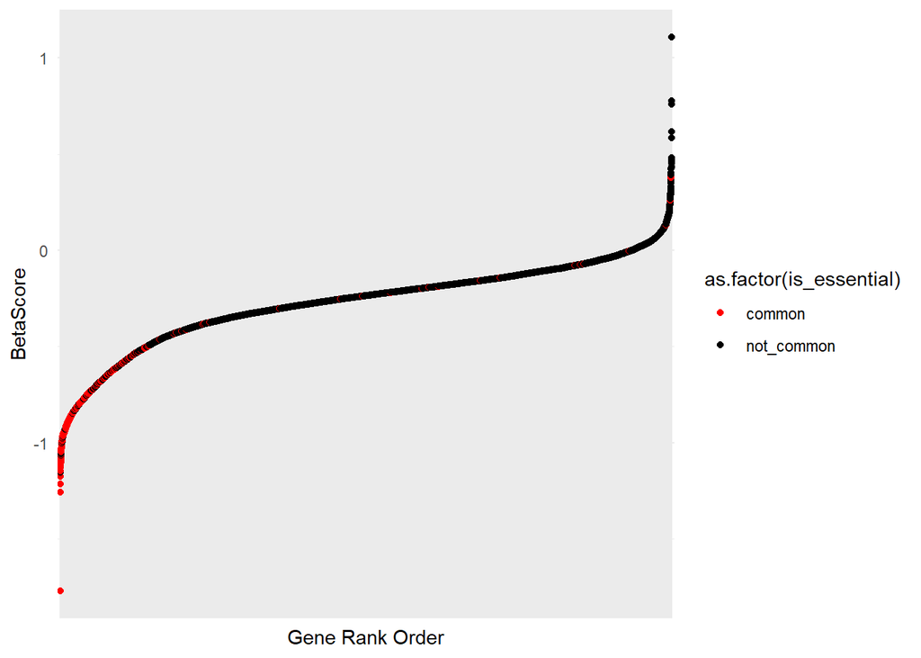

```r
ggplot(KitraScreen_v2) +
  geom_point(aes(x = reorder(Gene, BetaScore), y = BetaScore, color = as.factor(is_essential))) +
  scale_color_manual(values = c("common" = "red", "not_common" = "black")) +
  scale_size_manual(values = c("common" = 8, "not_common" = 2)) +
  labs(x = "Gene Rank Order", y = "BetaScore") +
  scale_x_discrete(expand = c(.005, .005)) +
  theme_minimal() +
  theme(axis.text.x = element_blank())
```

#Removing all the common essential genes, circa 2000, using dplyr

```r
glimpse(KitraScreen_v2)
```

```
## Rows: 18,771
## Columns: 5
## $ Gene             <chr> "LETM1", "RPL8", "EEFSEC", "MARS2", "FDX2", "RPL36", …
## $ CommonEssentials <chr> "LETM1", "RPL8", "EEFSEC", "MARS2", NA, "RPL36", "SNR…
## $ BetaScore        <dbl> -1.7694, -1.2561, -1.2144, -1.1744, -1.1540, -1.1468,…
## $ in_range         <chr> "Out of Range", "Out of Range", "Out of Range", "Out …
## $ is_essential     <chr> "common", "common", "common", "common", "not_common",…
```

```r
#18,771 genes

UncommonKitraData <- filter(KitraScreen_v2, is_essential == "not_common")

glimpse(UncommonKitraData)
```

```
## Rows: 16,728
## Columns: 5
## $ Gene             <chr> "FDX2", "MED16", "INTS10", "ELP4", "H3C14", "MCAT", "…
## $ CommonEssentials <chr> NA, NA, NA, NA, NA, NA, NA, NA, NA, NA, NA, NA, NA, N…
## $ BetaScore        <dbl> -1.15400, -1.06420, -1.05610, -1.04390, -1.01450, -1.…
## $ in_range         <chr> "Out of Range", "Out of Range", "Out of Range", "Out …
## $ is_essential     <chr> "not_common", "not_common", "not_common", "not_common…
```

```r
#16,728 genes
```

#Now take my CRISPR whole genome negative selection gene essentially data set, without common essential genes, and merge with RNA-seq and ChIP-seq data set containing genes whose transcripts are specifically up-regulated in CIC-DUX4 sarcoma, relative to all other sarcomas, and who have a CIC-DUX4 DNA binding sequence within their promoters

```r
library(readr)
CICDUX4_specific_genes <- read_csv("C:/Users/Student/Desktop/CICDUX4_specific genes.csv")
View(CICDUX4_specific_genes)

UncommonKitraData_joined <- UncommonKitraData %>%
  left_join(CICDUX4_specific_genes)
```

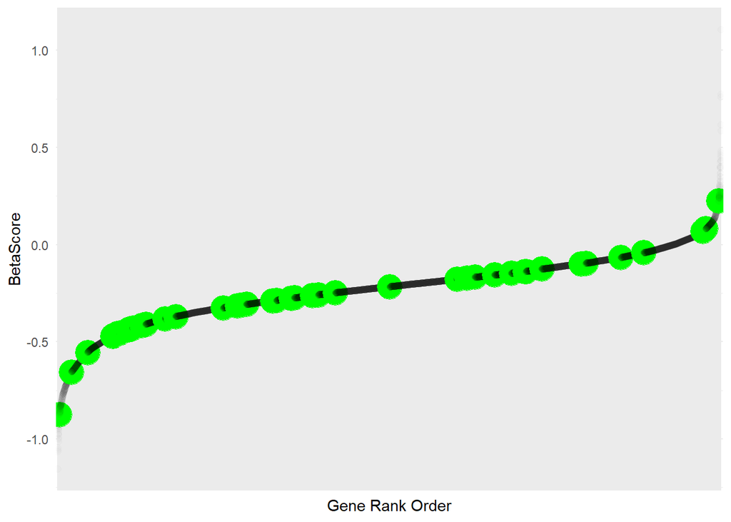

```r
UncommonKitraData_joined <- UncommonKitraData_joined %>%
                dplyr::mutate(CDSspecific = if_else(log2FoldChange_CDS_vs_OtherSarc > 0, "Specific", "not_specific"))


ggplot(UncommonKitraData_joined) +
  geom_point(aes(x = reorder(Gene, BetaScore), y = BetaScore, color = if_else(is.na(CDSspecific), "NA", "Specific"), alpha = if_else(is.na(CDSspecific), "NA", "Specific"), size = if_else(is.na(CDSspecific), "NA", "Specific"))) +
  scale_color_manual(values = c("black", "green")) +
  scale_alpha_manual(values = c(.01, 1))+
  scale_size_manual(values = c(2,8))+
  labs(x = "Gene Rank Order", y = "BetaScore") +
  scale_x_discrete(expand = c(.003, .003)) +
  theme_minimal() +
  theme(axis.text.x = element_blank()) +
  theme(legend.position = "none")
```

```r
CICDUX4_TopCandidates <- CICDUX4_specific_genes %>%
  left_join(UncommonKitraData)
CICDUX4_TopCandidates <- CICDUX4_TopCandidates %>% distinct()

glimpse(CICDUX4_TopCandidates)
```

```
## Rows: 47
## Columns: 7
## $ Gene                            <chr> "CRH", "TNR", "CNGB1", "COLEC11", "GCN…
## $ log2FoldChange_CDS_vs_OtherSarc <dbl> 7.721003, 7.154358, 7.079899, 6.105201…
## $ padj                            <dbl> 1.48078e-79, 5.58589e-29, 1.38047e-25,…
## $ CommonEssentials                <chr> NA, NA, NA, NA, NA, NA, NA, NA, NA, NA…
## $ BetaScore                       <dbl> -0.324850, -0.261670, -0.314360, -0.41…
## $ in_range                        <chr> "In Range", "In Range", "In Range", "O…
## $ is_essential                    <chr> "not_common", "not_common", "not_commo…
```

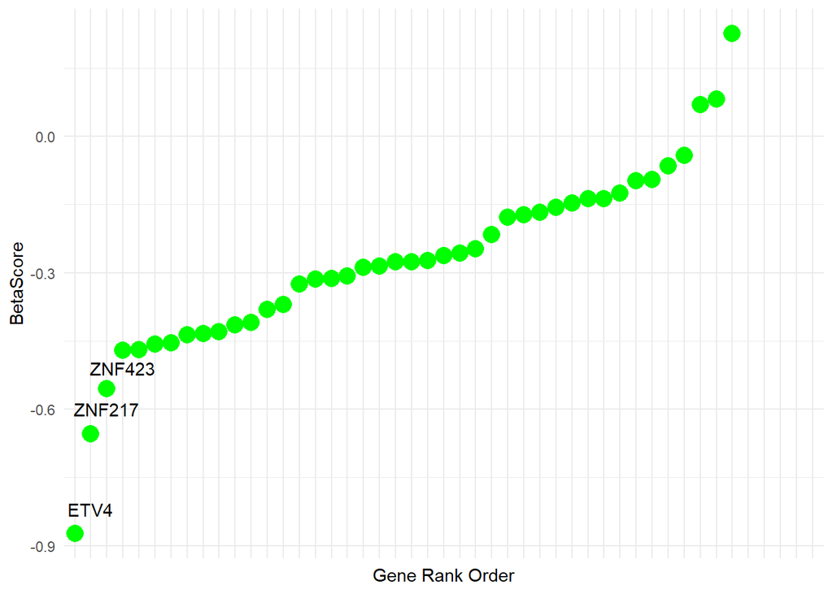

```r
#5 genes do not have a beta score because they were filtered out of the KitraScreen data.frame due to being common essential
#We thus have 42 genes that are NOT common essential, uniquely upregulated in CIC-DUX4 sarcoma, and have a CIC-DUX4 binding sequence within their promoter

ggplot(CICDUX4_TopCandidates) +
  geom_point(aes(x = reorder(Gene, BetaScore), y = BetaScore, color = "green", size = 5)) +
  scale_color_manual(values = c("green")) +
  labs(x = "Gene Rank Order", y = "BetaScore") +
  scale_x_discrete(expand = c(.015, .007)) +
  theme_minimal() +
  theme(axis.text.x = element_blank()) +
  theme(legend.position = "none")+
  annotate("text", x= 2, y= -.82, label = "ETV4") +
  annotate("text", x= 3, y= -.60, label = "ZNF217") +
  annotate("text", x= 4, y= -.51, label = "ZNF423")
```

#Conclusions #ETV4 is a known downstream target of the CIC-DUX4 fusion oncoprotein, giving credence to the biologic validity of my experiment (Okimoto et al. J Clin Invest. 2019). This is the first whole genome CRISPR screen done in CIC-DUX4 cell lines. ZNF217 and ZNF423 are unexplored in CIC-DUX4 sarcoma, though ZNF217 has recently been defined as a oncogenic driver in osteosarcoma (Smeester et al. Mol Cancer Ther. 2020)

#Prioritized Follow-up Studies #Validate ZNF217 and ZNF423 growth-inhibiting effect #Interaction with the principle oncogenic driver CIC-DUX4 #How does modulation of these zinc fingers impact cellular differention, cell death, invasion, and metastasis

#Acknowledgments #Thank you Wood Lab and everyone at Duke. Go Blue Devils!